# act_report

## Report: act_report

The questions possed for analysis were, What is the relationship between retweet count and favorite count, which source did the most tweets about dogs and their ratings come from and finaly What are the top 10 favorite dog breeds and which the most favorite.

- In addressing the first question, a scatter plot between favorite count and retweet count was created with retweet count on the x-axis and favorite count on the y-axis. The outcome showed that there was a strong positve correlation between Favorite count and Retweet count which suggests that tweets that are liked more are most often retweeted more as well. The Scatter plot is represented below.
- The second question was addressed by finding the value counts of the four different sources(Twitter for iPhone,Vine - Make a Scene,Twitter Web Client,TweetDeck) from which tweets came in. The values counts of the four sources were then plotted using a bar graph. It was oserved from the bar graph that the majority of the tweets about dogs annd their ratings were made from iphones. The bar graph is represented below.
- The third question needed insights as to which dog breeds were the top 10 favorite and finally which among them is the most favorite. This was addressed by using the mean favorite counts for each dog breed using the groupby function. The means were them ranked in descending order. The dog breed with the greatest mean is the most favorite. The first 10 biggest means were queried using the .head(10) and represented on a bar graph. From the bar grapgh,Bedlington_terrier had the highest mean favorite count making it the favorite breed of all. The breeds that made it to the top 10 are Bedlington_terrier, Saluki, French_bulldog, Bouvier_des_Flandres, Afghan_hound, Black-and-tan_coonhound, Irish_water_spaniel, Leonberg, Standard_poodle, and English_springer. The bar graph is represented below.

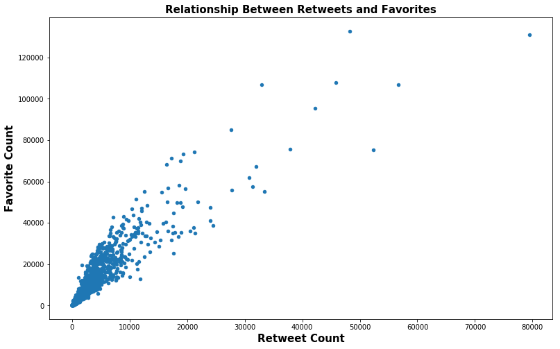

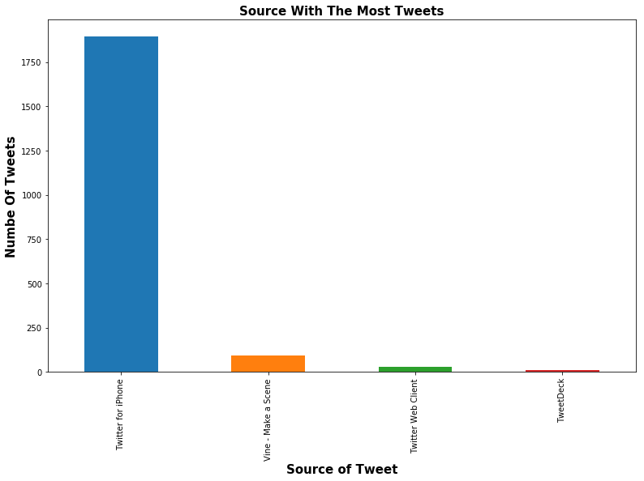

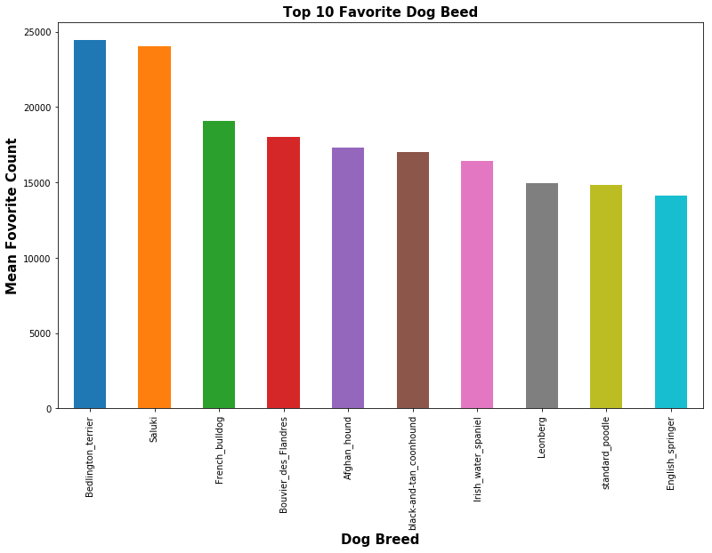